# Pierwsze kroki w R

7 października 2017

## Jak wydobyć informacje z danych?

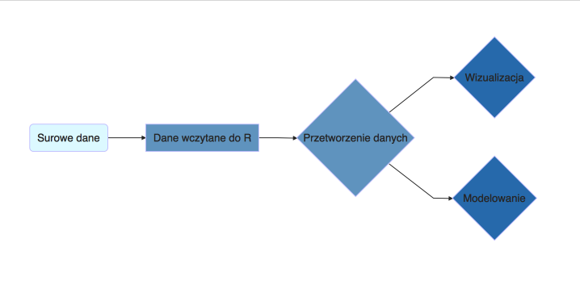

## Wczytanie danych

Do **R** można łatwo wczytywać dane z arkuszy kalkulacyjnych (.csv., .xls, .odt).

```r
mieszkania <- read.csv("data/mieszkania_wroclaw_ceny.csv",
                       encoding = "UTF-8")
```

Do zmiennej *mieszkania* przypisaliśmy wynik funkcji *read.csv*.

## Obiekty

```r
# wymiary tabeli
dim(mieszkania)
```

```
## [1] 5851    7
```

```r
# pierwsze wiersze z tabeli
head(mieszkania)
```

```
##   n_pokoj metraz cena_m2  rok pietro pietro_maks   dzielnica
## 1       3  89.00    5270 2007      2           2      Krzyki
## 2       4 163.00    6687 2002      2           2   Psie Pole
## 3       3  52.00    6731 1930      1           2 Srodmiescie
## 4       4  95.03    5525 2016      1           2      Krzyki
## 5       4  88.00    5216 1930      3           4 Srodmiescie
## 6       2  50.00    5600 1915      3           4      Krzyki
```

## Obiekty

```r
# podsumowanie tabeli
summary(mieszkania)
```

```
##     n_pokoj          metraz          cena_m2           rok
##  Min.   :1.000   Min.   : 17.89   Min.   : 1585   Min.   :1750
##  1st Qu.:2.000   1st Qu.: 47.71   1st Qu.: 5240   1st Qu.:1968
##  Median :3.000   Median : 58.63   Median : 5873   Median :1996
##  Mean   :2.701   Mean   : 63.47   Mean   : 6165   Mean   :1983
##  3rd Qu.:3.000   3rd Qu.: 74.00   3rd Qu.: 6667   3rd Qu.:2010
##  Max.   :7.000   Max.   :417.00   Max.   :25000   Max.   :2018
##      pietro        pietro_maks            dzielnica
##  Min.   : 0.000   Min.   : 0.000   Fabryczna   :1370
##  1st Qu.: 1.000   1st Qu.: 2.000   Krzyki      :2021
##  Median : 2.000   Median : 4.000   Psie Pole   : 688
##  Mean   : 2.513   Mean   : 3.988   Srodmiescie : 999
##  3rd Qu.: 3.000   3rd Qu.: 5.000   Stare Miasto: 773
##  Max.   :16.000   Max.   :30.000
```

[figure not shown]

## Przetwarzanie danych

## Filtrowanie wierszy

```r
library(dplyr)
filter(mieszkania, dzielnica == "Stare Miasto")
```

```
##     n_pokoj metraz cena_m2  rok pietro pietro_maks    dzielnica
## 1         2  46.00    9761 2011      4           6 Stare Miasto
## 2         3  90.00    7544 2013      2           5 Stare Miasto
## 3         3  74.25    4916 1960      3           4 Stare Miasto
## 4         2  62.00    7403 1900      2           4 Stare Miasto
## 5         4  45.00    8444 1900      2           4 Stare Miasto
## 6         1  40.00    7175 1950      3           5 Stare Miasto
## 7         2  50.55    6330 1950      3           5 Stare Miasto
## 8         3  41.00    8512 1968      1           4 Stare Miasto
## 9         2  54.00   10185 2008      4           8 Stare Miasto
## 10        1  24.30    8889 2017      5           7 Stare Miasto
## 11        2  47.20    6335 1980      0           0 Stare Miasto
## 12        1  48.30   17578 2007      4           5 Stare Miasto
## 13        2  38.45   10401 2017      6           6 Stare Miasto
## 14        4 136.95    6418 1903      0           0 Stare Miasto
```

[output cut: 759 more lines]

Warunki mozna łączyć

```r
filter(mieszkania, dzielnica == "Stare Miasto", rok == 2017)
```

```
##    n_pokoj metraz cena_m2  rok pietro pietro_maks    dzielnica
## 1        1  24.30    8889 2017      5           7 Stare Miasto
## 2        2  38.45   10401 2017      6           6 Stare Miasto
## 3        2  47.09    6795 2017      4           6 Stare Miasto
## 4        3  54.68    6748 2017      5           6 Stare Miasto
## 5        2  47.10    6900 2017      5           6 Stare Miasto
## 6        2  46.23   11464 2017      6           6 Stare Miasto
## 7        2  46.23   11573 2017      5           6 Stare Miasto
## 8        3  55.20    6500 2017      6           8 Stare Miasto
## 9        3  47.29    6100 2017      3           5 Stare Miasto
## 10       2  34.29    6400 2017      0           0 Stare Miasto
## 11       2  77.00   10269 2017      2           5 Stare Miasto
## 12       2  33.00    6751 2017      4           5 Stare Miasto
## 13       2  55.30    7475 2017      3           9 Stare Miasto
## 14       2  37.13    7500 2017      2           6 Stare Miasto
## 15       3  56.00    6500 2017      2           6 Stare Miasto
## 16       2  45.00    6533 2017      2           6 Stare Miasto
## 17       3  71.00    6183 2017      4           6 Stare Miasto
## 18       1  24.20   10086 2017      1           4 Stare Miasto
## 19       2  41.32    6994 2017      5           5 Stare Miasto
## 20       3  54.68    6748 2017      5           6 Stare Miasto
## 21       2  47.09    6795 2017      4           6 Stare Miasto
## 22       2  45.11    6500 2017      1           8 Stare Miasto
## 23       2  45.09    6500 2017      1           8 Stare Miasto
## 24       3  61.66    6450 2017      3           8 Stare Miasto
## 25       3  54.68    6748 2017      5           6 Stare Miasto
## 26       3  54.68    6748 2017      5           6 Stare Miasto
## 27       2  47.09    6795 2017      4           6 Stare Miasto
## 28       2  36.73    7215 2017      6           6 Stare Miasto
## 29       2  48.19    6537 2017      1           5 Stare Miasto
```

## Co jeszcze potrafi dplyr? Może nie interesuje nas nic poza ceną i dzielnicą?

```r
select(mieszkania, dzielnica, cena_m2)
```

```
##         dzielnica cena_m2
## 1          Krzyki    5270
## 2       Psie Pole    6687
## 3     Srodmiescie    6731
## 4          Krzyki    5525
## 5     Srodmiescie    5216
## 6          Krzyki    5600
## 7       Fabryczna    9146
## 8    Stare Miasto    9761
## 9       Fabryczna    5209
## 10         Krzyki    6878
## 11      Psie Pole    8684
## 12         Krzyki    6327
## 13         Krzyki    3586
## 14      Psie Pole    5369
```

[output cut: 5837 more lines]

Te komendy można ze sobą łączyć w tak zwane strumienie (pipes).

```r
mieszkania %>%
  filter(dzielnica == "Srodmiescie") %>%
  select(dzielnica, pietro, cena_m2)
```

```
##       dzielnica pietro cena_m2
## 1   Srodmiescie      1    6731
## 2   Srodmiescie      3    5216
## 3   Srodmiescie      5    6340
## 4   Srodmiescie      0    6968
## 5   Srodmiescie      3    5303
## 6   Srodmiescie      1    7341
## 7   Srodmiescie      4    4621
## 8   Srodmiescie      5    6185
## 9   Srodmiescie      4    6918
## 10  Srodmiescie      3    6735
## 11  Srodmiescie      6    8500
## 12  Srodmiescie      3    6628
## 13  Srodmiescie      1    7211
## 14  Srodmiescie      1    5755
```

[output cut: 985 more lines]

## Co potrafimy już zrobić?

- wybrać poszczególne wiersze za pomocą warunków logicznych (filter)
- wybrać poszczególne kolumny (select)

## Podsumowania

Podsumowania pozwalają obliczyć statystykę agregującą dla grupy daych. Np. ile średnio kosztują mieszkania w zależności od liczby pokojów lub piętra.

```r
mieszkania %>%
  group_by(n_pokoj) %>%
  summarise(srednia_cena = mean(cena_m2))
```

```
## # A tibble: 7 x 2
##   n_pokoj srednia_cena
##     <int>        <dbl>
## 1       1     7258.169
## 2       2     6343.555
## 3       3     5965.009
## 4       4     5800.999
## 5       5     5896.369
## 6       6     7020.875
## 7       7     6572.231
```

Jak wiadomo jeden wykres znaczy więcej niż tysiąc tabel. Zróbmy zatem prostą wizualizację.

```r
library(ggplot2)
srednia_cena_pokoje <- mieszkania %>%
  group_by(n_pokoj) %>%
  summarise(srednia_cena = mean(cena_m2))
```

```r
ggplot(srednia_cena_pokoje, aes(x = n_pokoj, y = srednia_cena))
```

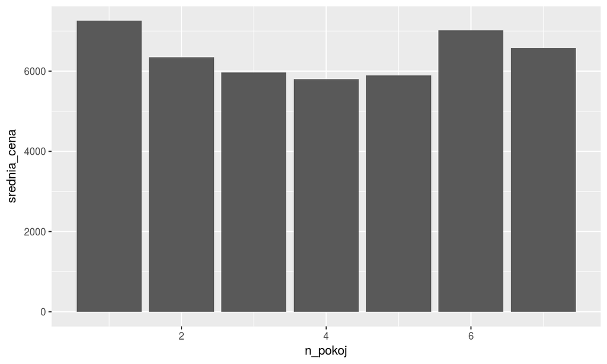

```r
ggplot(srednia_cena_pokoje, aes(x = n_pokoj, y = srednia_cena)) +
  geom_bar(stat = "identity")
```

## Zadania

1. Odfiltruj jedynie nieruchomości z Psiego Pola o liczbie pokojów większej niż 2
2. Wybierz zmienne związane z piętrem i metrażem
3. Odfiltruj nieruchomości ze Śródmieścia i zapisz do nowej zmiennej
4. Odfiltruj nieruchomości z Krzyków i wyświetl jedynie informacje o piętrze, na którym znajduje się mieszkanie i liczbie pięter w budynku
5. Znajdź średnią cenę \(m^2\) w każdej dzielnicy
6. Narysuj wykres słupkowy, na którym przedstawisz cenę \(m^2\) w każdej dzielnicy

## Rozwiązania

## Odfiltruj jedynie nieruchomości z Psiego Pola o liczbie pokojów większej niż 2

```r
mieszkania %>%
  filter(dzielnica == "Psie Pole", n_pokoj > 2) %>%
  head
```

```
##   n_pokoj metraz cena_m2  rok pietro pietro_maks dzielnica
## 1       4  163.0    6687 2002      2           2 Psie Pole
## 2       3   76.0    8684 1930      0           0 Psie Pole
## 3       3   65.0    5369 1990      8          10 Psie Pole
## 4       3   66.7    5232 1935      1           2 Psie Pole
## 5       3   63.3    4408 1930      0           0 Psie Pole
## 6       3   59.6    4530 1925      3           3 Psie Pole
```

## Wybierz zmienne związane z piętrem i metrażem

```r
mieszkania %>%
  select(pietro, metraz)
```

```
##      pietro metraz
## 1         2  89.00
## 2         2 163.00
## 3         1  52.00
## 4         1  95.03
## 5         3  88.00
## 6         3  50.00
## 7         2  48.00
## 8         4  46.00
## 9         1  67.00
## 10        3  45.80
## 11        0  76.00
## 12        3  24.50
## 13        1  47.41
## 14        8  65.00
```

[output cut: 5837 more lines]

## Odfiltruj nieruchomości ze Śródmieścia i zapisz do nowej zmiennej

```r
mieszkania_srodmiescie <- mieszkania %>%
  filter(dzielnica == "Srodmiescie")
```

## Odfiltruj nieruchomości z Krzyków…

…i wyświetl jedynie informacje o piętrze, na którym znajduje się mieszkanie i liczbie pięter w budynku

```r
mieszkania %>%
  filter(dzielnica == "Krzyki") %>%
  select(pietro, pietro_maks)
```

```
##      pietro pietro_maks
## 1         2           2
## 2         1           2
## 3         3           4
## 4         3           4
## 5         3           3
## 6         1           3
## 7         0           0
## 8         2           4
## 9         1          10
## 10        0           0
## 11        3           3
## 12        0           0
## 13        2           3
## 14        4           4
```

[output cut: 2007 more lines]

## Znajdź średnią cenę \(m^2\) w każdej dzielnicy

```r
srednia_cena_dzielnice <- mieszkania %>%
  group_by(dzielnica) %>%
  summarise(srednia_cena = mean(cena_m2))
```

## Narysuj wykres słupkowy, na którym przedstawisz cenę \(m^2\) w każdej dzielnicy

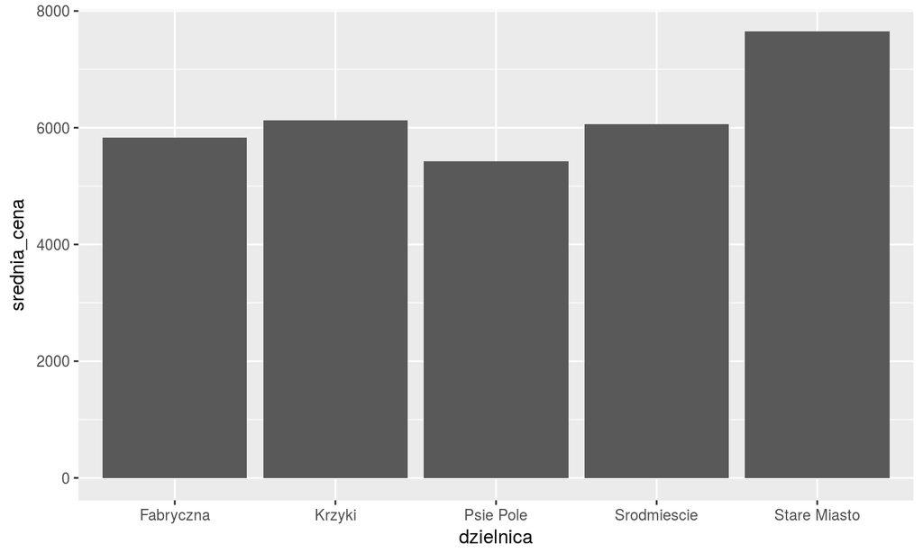

```r
ggplot(srednia_cena_dzielnice, aes(x = dzielnica, y = srednia_cena)) +
  geom_bar(stat = "identity")
```